# Simple AB Testing of Search Keywords in R

Alex Heaton

### Summary

This is an example of AB testing of search keywords from the [open-advertising-dataset](https://code.google.com/p/open-advertising-dataset/). The source of this data is not identified but it seems to provide data on click and costs from Google AdWords bids in the UK. The data is broken up into 170 csv files one for each day-and there are about 100,000 individual records after all of the csv files are combined.

Here a visualization of the top 50 keywords in terms of the clicks. The color of the bar indicates the cost per click (CPC) with light blue bars getting 50-60 British Pounds per click. (This chart excludes the #1 search term “free” because it is so high it skews the chart.)

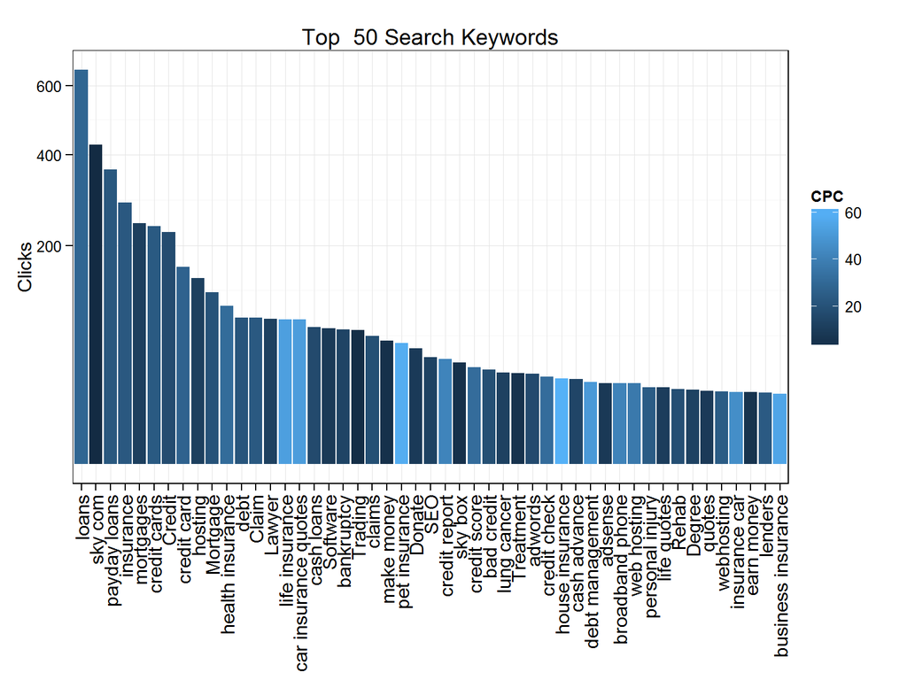

### Defining the AB Test “online trading” or “stock trading”

Let’s imagine that I am marketing manager for an online brokerage and I want to determine what keyword gives me the best cost per click “**online trading**” or “**stock trading**” (I picked these terms because they have very similar performance so statistical analysis is required to determine which one performs better.)

First let’s load the data from the csv files and have a look:

```
##           Keyword  CPC Clicks CTR   Cost Impressions searchDate
## 9  online trading 9.03  90.46 5.5 816.84        1632 2012-07-30
## 10  stock trading 6.34 106.74 5.4 677.19        1990 2012-07-30
```

### AB Test #1: Test Results from a Single Day

[output not shown]

On this day “online trading” has a slightly higher CTR than “stock trading”. But I need to do more analysis to determine if this is a meaningful difference. I will use a Chi-squared Test determine if “online trading” really performs better of if the difference is due to chance.

```
##                    Response
## Keyword             Click NoClick
##   a: online trading    90    1512
##   b: stock trading    107    1870
```

```
##
##  Pearson's Chi-squared test with Yates' continuity correction
##
## data:  Conversions
## X-squared = 0.037891, df = 1, p-value = 0.8457
```

The key figure we need to check is the p-value. In general, if the p-value is less than 0.05 we can trust that there is a meaningful difference between the two groups. And we can reject the NULL hypothesis that the mean CTR of the two terms is the same.

In this case, the p-value is 0.845, which is very high. So I can’t determine if any keyword is better than the other.

### AB Test #2: Test All Data

In order to decrease the p-value I need to test more data, across more than one day. So I am going to test the data from all 170 days.

```
## Source: local data frame [2 x 6]
##
##          Keyword   CPC   Clicks     Cost      CTR Impressions
## 1 online trading 12.29 17585.40 187785.7 3.535079      497959
## 2  stock trading 13.59 17220.03 133917.9 2.829319      585008
```

```
##
##  Pearson's Chi-squared test with Yates' continuity correction
##
## data:  Conversions
## X-squared = 401.62, df = 1, p-value < 2.2e-16
```

This time, with all the data, the p-value is practically zero so I feel confident that “online trading” is the better performing keyword–it has a higher click-through-rate and lower CPC.

So the next step is to figure out the minimum number of days (sample size) that I need to run this test and get a significant result.

### Determining the Best Sample Size

The technique to estimate the optimal, minimal size is called statistical power. Statistical power is the probability that a study will accurately detect the difference if there is an effect there to be detected. If statistical power is high, the probability of detecting the difference between the two groups go up.

- w: This is the size of the differience you are trying to detect. In my case I estimate that the average CTR is 4.0% and I want to any of the words perform .5% better. I enter those values into the ES.w1 funtion and it returns a value of .025.
- df: Degrees-of-freedom is calculated as (n of xaxis -1)*(n of yaxis-1). In this case we have a 2x2 table so the df works out to be one.
- sig.level is .05, consistent with our other p-value tests
- power, I set at .9, which we want to make sure or chance of detecting the effect is 90%.

```
## Source: local data frame [2 x 6]
##
##          Keyword  CPC  Clicks    Cost  CTR Impressions
## 1 online trading 7.78  966.61 7473.09 4.90       19894
## 2  stock trading 6.59 1014.23 6676.97 4.69       21793
```

```
##
##  Pearson's Chi-squared test with Yates' continuity correction
##
## data:  Conversions
## X-squared = 4.0385, df = 1, p-value = 0.04447
```

So I should pick “online trading” right? Remember my goal is to find the keyword with the lowest CPC. And “stock trading” actually has the lowest CPC with 6.59.

But before I pick “stock trading” I want to do one more test. I want to know if the differences in the CPC are really statistically significant. I will use another kind of test called the t-test to test the means of the CPC for those 10 days.

```
##
##  Welch Two Sample t-test
##
## data:  online.cpc and stock.CPC
## t = 2.8259, df = 16.886, p-value = 0.01171
## alternative hypothesis: true difference in means is not equal to 0
## 95 percent confidence interval:
##  0.3003298 2.0736702
## sample estimates:
## mean of x mean of y
##     7.778     6.591
```

The p-value is very low (0.01) and furthermore the confidence interval is 0.30 - 2.07. Meaning that we have at least 95% confidene that the difference between the two keywords is not zero and is between .3 and 2.

## Conclusion

So I chose “stock trading” as the keyword for my campaign.

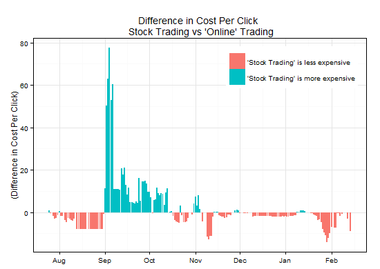

For most months Stock Trading is the least expensive keyword. But in September, the price of Stock Trading spikes which is why it is more expensive on average for the whole time period.

Since the relative price of the keywords is constantly changing, the best strategy is not to pi ck one keyword, no matter how much you test it. But rather to continuually monitor and optimize your bids to make sure that you are making the smartest choices.